# Lab 001

Data cleaning

Andrew Dickinson

14 January 2022

## Introduction

In an effort to make this lab as useful as possible, I am going to change things up a little bit from last week.

- Going to try to move away from lecture slides, standing in the front of the room with a clicker
- Be more active; live coding; working with data (that you are using in your projects) in front of you all
- Sit down and code more rather talk about it
- Give more tips and tricks; provide examples and code snippets

As the quarter progresses, I hope to spend more time providing materials, tips/tricks, methods etc. for helping you all finish the projects and understand how to code what we are doing in class.

I will continue to make adjustments to lab to make this time more productive- any feedback is greatly appreciated.

Furthermore, I am keeping a list of “miscellaneous” topics to go over that I have found super helpful. Let me know if there are any particular topics you all are interested in!

#### Last week

We talked about:

- Rstudio
- Projects in Rstudio
- Pipe operators
- `dplyr` verbs (ran out of time for most of these)
  - `select()`
  - `filter()`
  - `arrange()`
  - `mutate()`
  - `group_by` + `summarize()`

This week I want to apply these topics with an actual project- **project-000**

## Outline

(i.) Setup project-000

- File management
- Using `here()`
- Writing scripts

(ii.) Question 03 *“Get a feel for the data- graphs, summaries, etc”*

- View()
- skim()
- clean_names()
- Using pipes, `dpylr` and `ggplot2`

(iii.) Coding errors

- Erik’s coding error
  - Namespace conflicts
- How to google for help

## Setup project-000

**First** open up Rstudio and close any projects; start a new project - I recommend a new Rstudio project for each project in this class

*Note:* Having a **clean** and **organized** file system is extremely important!

Here’s how I would set up my filesystem:

`Home > Documents > classes > prediction > projects > project-000`

Within `project-000` I would create two folders, one for r scripts/markdown called `R/` and one for data called `data/`

I have posted the a [link](https://github.com/edrubin/EC524W22/raw/master/lab/001-cleaning/data/house-prices-advanced-regression-techniques.zip) to a `.zip` file of the housing data on the `README.md`. Download this to your `data/` folder and unzip it

For simplicity I copied Ed’s `data.table()` code from from Connor Lennon’s [Rpubs page](https://rpubs.com/Clennon/KagNotes) page on kaggle notebooks on a new `R` script

*Note: Let me know if you guys are interested in learning about `data.table`!!*

## “Get a feel for the data”

Question 03 (bullet 2) says “Get a feel for the data- graphs, summaries, etc”

**I cannot stress enough how important it is that you do this with each new dataset you come across!**

Before you ever run a regression:

- plot the data to look for patterns
- Look at the data set using `View()`, `glimpse()`, or `skimr::skim()`

#### Sidebar: Codebooks

Codebooks are extremely useful for understanding variables and what the heck the variable names mean. Read the codebook always.

- I like to print them out and tape them to my wall

Let’s use `dplyr` and `ggplot2` to plot the data using pipe operators!

In class example of how to use these two packages to analyze different cuts of housing data

*Note: this is really simple visualization with little forethought.. Just a showcase of how to use these packages together!*

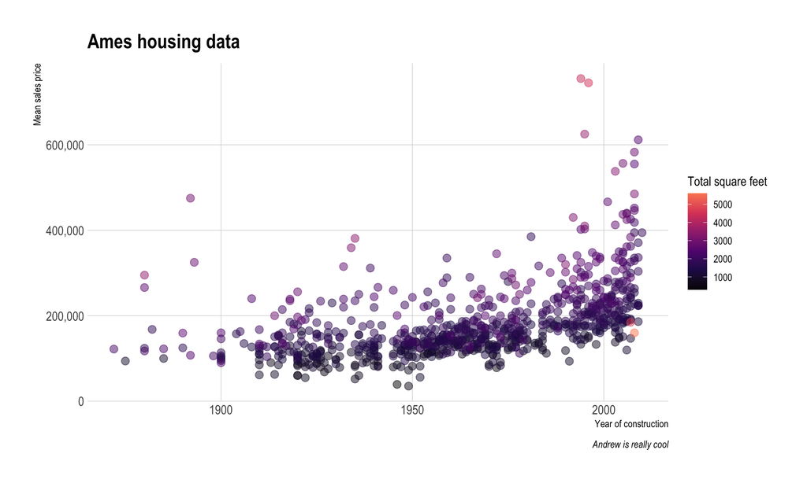

```r
train_dt_new = train_dt %>%
  janitor::clean_names('upper_camel')

train_dt_new %>%
  rename(FirstFloorSF = X1StFlrSf,
         SecondFloorSF = X2NdFlrSf) %>%
  mutate(TotalSqFt = FirstFloorSF + SecondFloorSF,
         TotalSqFt_binned = round(TotalSqFt, digits = -2)) %>%
  group_by(TotalSqFt_binned, YearBuilt) %>%
    summarize(MeanSalePrice = mean(SalePrice),
              MeanOverallQual = mean(OverallQual)) %>%
  ungroup() %>%
  mutate(PostWWII = ifelse(YearBuilt > 1945, "Post WWII", "Pre WWII")) %>%
  ggplot(aes(x = YearBuilt, y = MeanSalePrice,  color = TotalSqFt_binned)) +
    geom_point(alpha = 0.5, size = 3) +
    hrbrthemes::theme_ipsum() +
    theme(
      panel.grid.minor = element_blank(),
      legend.position = 'right'
      # panel.grid.minor = element_blank()
    ) +
    labs(
      x = "Year of construction",
      y = "Mean sales price",
      title = "Ames housing data",
      caption = "Andrew is really cool",
      color = 'Total square feet'
    ) +
    # facet_wrap(~ PostWWII) +
    scale_y_continuous(labels = scales::comma) +
    scale_x_continuous(breaks = seq(1900, 2010, 50)) +
    scale_color_viridis_c(option = 'magma', begin = 0, end = 0.75) +
    scale_size_continuous(range = c(0.2,3))
```

## Coding errors

First, how is the project going? Is anyone struggling with any errors that they need help with?

```r
# Train a model --------------------------------------------------------------------------
# Train the model
model_trained = rand_forest(mode = "regression", mtry = 12, trees = 10000) %>%
  set_engine("ranger", seed = 12345, num.threads = 10) %>%
  fit_xy(
    y = train_dt[,SalePrice],
    x = train_dt[,-c("Id", "SalePrice")] %>%
      select(MSSubClass:Foundation, KitchenQual, PoolArea:SaleCondition)
  )
# Predict onto testing data
new_predictions = predict(
  model_trained,
  new_data = test_dt
)
# Data to submit
# NOTE: Names and capitalization matter
to_submit = data.frame(
  Id = test_dt$Id,
  SalePrice = new_predictions$.pred
)
# # File to submit
# write_csv(
#   x = to_submit,
#   path = here("data", "to-submit-001.csv")
# )
```

```r
# Train a model --------------------------------------------------------------------------
#- testing performance

model_trained_new = lm(SalePrice ~ LotArea,
                         data = train_dt)

# predictions_testing = predict(
#   object = model_trained_new,
#   new_data = test_dt
# ) %>% as.data.frame()
#
# test_performance = data.frame(
#   Id = test_dt$Id,
#   SalePrice = predictions_testing$.
# )
```

```r
# Train a model --------------------------------------------------------------------------
#- testing performance

model_trained_new = lm(SalePrice ~ LotArea,
                         data = train_dt)

predictions_testing = predict(
  object = model_trained_new,
  newdata = test_dt
) %>% as.data.frame()

test_performance = data.frame(
  Id = test_dt$Id,
  SalePrice = predictions_testing$.
)
```